# PR_WQ

The purpose of this RMarkdown is to wrangle and clean pH, hardness, nitrate, pesticide, lead, and arsenic data from the Water Quality Portal (WQP).

```r
library(EPATADA)
library(tidyverse)
library(sf)
library(FSA)
```

Querying the WQP data.

```r
# specifying a list of dates I want to query (when I try to query data from 2000-01-01 to 2024-12-31 I get an error)
years <- list(
  c("2000-01-01", "2004-12-31"),
  c("2005-01-01", "2009-12-31"),
  c("2010-01-01", "2014-12-31"),
  c("2015-01-01", "2019-12-31"),
  c("2020-01-01", "2024-12-31")
)

ALPhysical <- purrr::map_dfr(years, \(y) {
  TADA_DataRetrieval(
    state = "AL",
    startDate = y[1],
    endDate = y[2],
    sampleMedia = c("water", "Water"),
    characteristicType = "Physical",
    siteType = "Well",
    applyautoclean = FALSE,
    ask = FALSE)
  })

write.csv(ALPhysical, "../input/raw/WQP/ALPhysical.csv")

ALNutrient <- purrr::map_dfr(years, \(y) {
  TADA_DataRetrieval(
    state = "AL",
    startDate = y[1],
    endDate = y[2],
    sampleMedia = c("water", "Water"),
    characteristicType = "Nutrient",
    siteType = "Well",
    applyautoclean = FALSE,
    ask = FALSE)
  })

write.csv(ALNutrient, "../input/raw/WQP/ALNutrient.csv")

# ALPesticides <- purrr::map_dfr(years, \(y) {
#   TADA_DataRetrieval(
#     state = "AL",
#     startDate = y[1],
#     endDate = y[2],
#     sampleMedia = c("water", "Water"),
#     characteristicType = "Organics, Pesticide",
#     siteType = "Well",
#     applyautoclean = FALSE,
#     ask = FALSE)
#   })
#
# write.csv(ALPesticides, "../input/raw/WQP/ALPesticides.csv")

ALMetals <- purrr::map_dfr(years, \(y) {
  TADA_DataRetrieval(
    state = "AL",
    startDate = y[1],
    endDate = y[2],
    sampleMedia = c("water", "Water"),
    characteristicName = c("Arsenic", "Lead"),
    siteType = "Well",
    applyautoclean = FALSE,
    ask = FALSE)
  })

write.csv(ALMetals, "../input/raw/WQP/ALMetals.csv")
```

Reading in all the files above (besides pesticides)

```r
ALMetals <- read.csv("../input/raw/WQP/ALMetals.csv")

ALNutrient <- read.csv("../input/raw/WQP/ALNutrient.csv")

ALPhysical <- read.csv("../input/raw/WQP/ALPhysical.csv")
```

Completing an initial cleaning for each dataframe.

```r
TDPhysical <- ALPhysical %>%
  TADA_AutoClean() %>%
  TADA_AnalysisDataFilter( . , clean = TRUE, ground_water = TRUE, sediment = FALSE, other = FALSE, surface_water = FALSE) %>%
  filter(ActivityMediaSubdivisionName == "Groundwater" | ActivityMediaSubdivisionName == "Ground Water")
```

[output not shown]

```r
# ALPhysical has 6139 observations, TDPhysical has 5981 observations

TDNutrient <- ALNutrient %>%
  TADA_AutoClean() %>%
  TADA_AnalysisDataFilter( . , clean = TRUE, ground_water = TRUE, sediment = FALSE, other = FALSE, surface_water = FALSE) %>%
  filter(ActivityMediaSubdivisionName == "Groundwater" | ActivityMediaSubdivisionName == "Ground Water")
```

[output not shown]

```r
# ALNutrient haS 3940 observations, TDNutrient has 3861 observations

# TDPesticides <- ALPesticides %>%
#   TADA_AutoClean() %>%
#   TADA_AnalysisDataFilter( . , clean = TRUE, ground_water = TRUE, sediment = FALSE, other = FALSE, surface_water = FALSE) %>%
#   filter(ActivityMediaSubdivisionName == "Groundwater" | ActivityMediaSubdivisionName == "Ground Water")
# ALPesticides has 58965 observations, TDPesticides has 58947 observations

TDMetals <- ALMetals %>%
  TADA_AutoClean() %>%
  TADA_AnalysisDataFilter( . , clean = TRUE, ground_water = TRUE, sediment = FALSE, other = FALSE, surface_water = FALSE) %>%
  filter(ActivityMediaSubdivisionName == "Groundwater" | ActivityMediaSubdivisionName == "Ground Water")
```

[output not shown]

```r
# ALMetals has 508 observations, TDMetals has 476 observations
```

Creating dataframes for each water quality parameter of interest.

```r
ph_data <- TDPhysical %>%
  filter(TADA.CharacteristicName == "PH")
# 830 observations

# hardness_columns <- TDPhysical %>%
#   filter(TADA.CharacteristicName %in% c(
#     "HARDNESS, CA, MG",
#     "HARDNESS, CARBONATE",
#     "HARDNESS, NON-CARBONATE",
#     "TOTAL HARDNESS"
#   ))
#
# hardness_summary <- TADA_SummarizeColumn(hardness_columns, "TADA.CharacteristicName")

# "HARDNESS, CA, MG" has the most entries so I will use that variable to represent hardness

hardness_data <- TDPhysical %>%
  filter(TADA.CharacteristicName == "HARDNESS, CA, MG")
# 309 observations

nitrate_data <- TDNutrient %>%
  filter(TADA.CharacteristicName == "NITRATE")
# 778 observations

arsenic_data <- TDMetals %>%
  filter(TADA.CharacteristicName == "ARSENIC")
# 238 observations

lead_data <- TDMetals %>%
  filter(TADA.CharacteristicName == "LEAD")
# 238 observations

# now I still want a dataframe containing all parameters of interest
all_params <- bind_rows(ph_data, hardness_data, nitrate_data, arsenic_data, lead_data)
# 2393 observations
```

Making sure all coordinates are valid

```r
# This function will flag imprecise coordinates or coordinates outside the US
clean_coords <- TADA_FlagCoordinates(all_params, clean_outsideUSA = "no", clean_imprecise = FALSE, flaggedonly = FALSE)

unique(clean_coords$TADA.SuspectCoordinates.Flag)
```

```
## [1] "Pass"                             "Imprecise_lessthan3decimaldigits"
```

```r
# [1] "Pass"                             "Imprecise_lessthan3decimaldigits"

# I am not going to remove any entries based on these flags
```

This next chunk of code flags entries based on method, fraction, speciation, and result unit.

```r
flagged_method <- TADA_FlagMethod(all_params, clean = FALSE)
```

```
## [1] "No Suspect method/characteristic combinations in your dataframe. Returning the input dataframe with TADA.AnalyticalMethod.Flag column for tracking."
```

```r
# [1] "No Suspect method/characteristic combinations in your dataframe. Returning the input dataframe with TADA.AnalyticalMethod.Flag column for tracking."

flagged_fraction <- TADA_FlagFraction(flagged_method, clean = FALSE)
```

```
## [1] "TADA_FlagFraction: Rows with Suspect sample fractions have been flagged but retained. Review these rows using the TADA.SampleFraction.Flag column before proceeding and/or set clean = TRUE."
```

```r
# [1] "TADA_FlagFraction: Rows with Suspect sample fractions have been flagged but retained. Review these rows using the TADA.SampleFraction.Flag column before proceeding and/or set clean = TRUE."

flagged_speciation <- TADA_FlagSpeciation(flagged_fraction, clean = "none")
```

```
## [1] "TADA_FlagSpeciation: Rows with Suspect speciations have been flagged but retained. Review these rows using the new TADA.MethodSpeciation.Flag column before proceeding and/or set clean = 'suspect_only' or 'both'."
```

```r
# [1] "TADA_FlagSpeciation: Rows with Suspect speciations have been flagged but retained. Review these rows using the new TADA.MethodSpeciation.Flag column before proceeding and/or set clean = 'suspect_only' or 'both'."

flagged_QC <- TADA_FindQCActivities(flagged_speciation, clean = FALSE)

flagged_result_unit <- TADA_FlagResultUnit(flagged_QC, clean = "none")
```

```
## [1] "TADA_FlagResultUnit: All characteristic/unit combinations are valid in your dataframe. Returning input dataframe with TADA.ResultUnit.Flag column for tracking."
```

```r
# [1] "TADA_FlagResultUnit: All characteristic/unit combinations are valid in your dataframe. Returning input dataframe with TADA.ResultUnit.Flag column for tracking."
# ends with 2393 observations
```

Now let’s take a look at what’s been flagged.

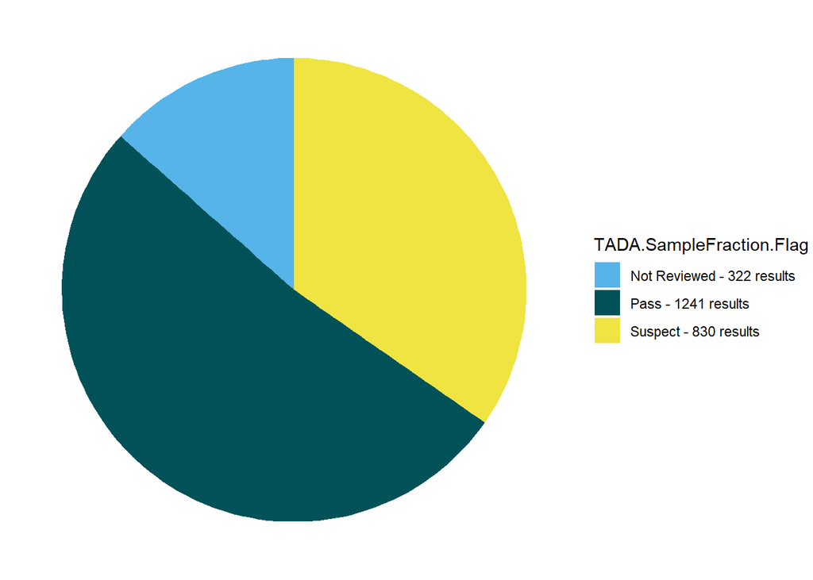

```r
TADA_FieldValuesPie(flagged_result_unit, field = "TADA.SampleFraction.Flag")
```

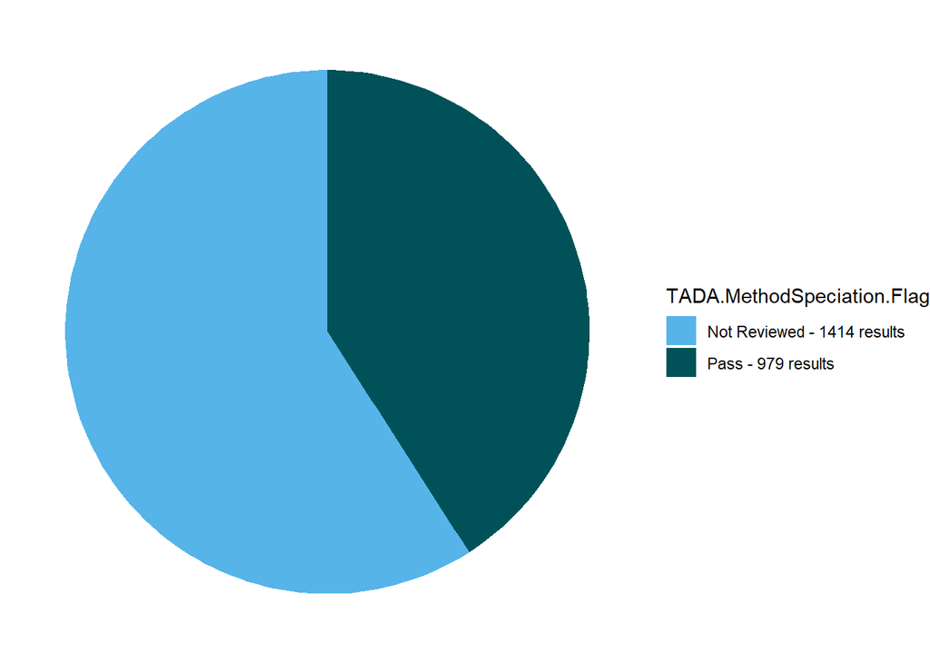

```r
TADA_FieldValuesPie(flagged_result_unit, field = "TADA.MethodSpeciation.Flag")
```

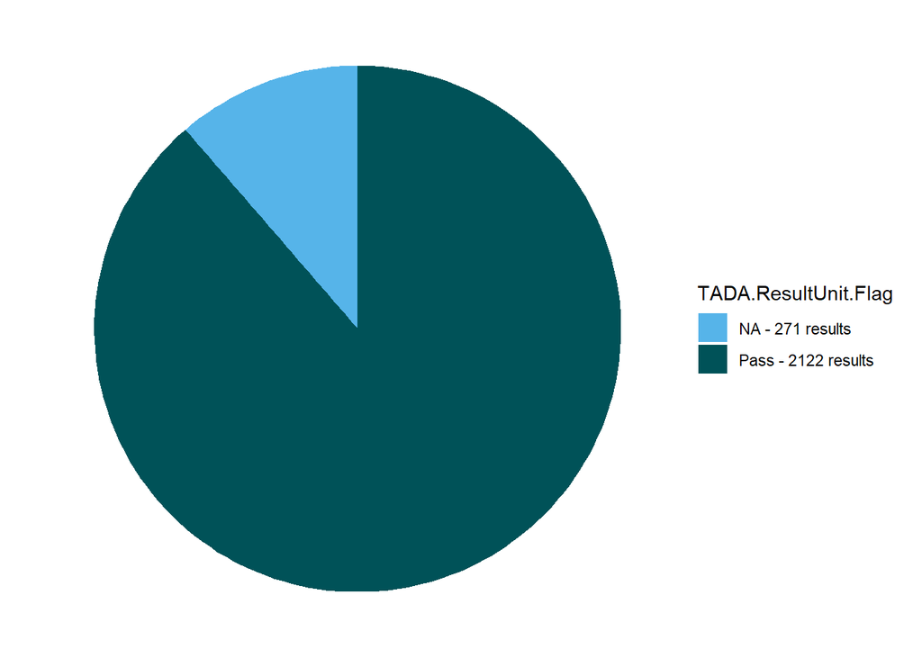

```r
TADA_FieldValuesPie(flagged_result_unit, field = "TADA.ResultUnit.Flag")
```

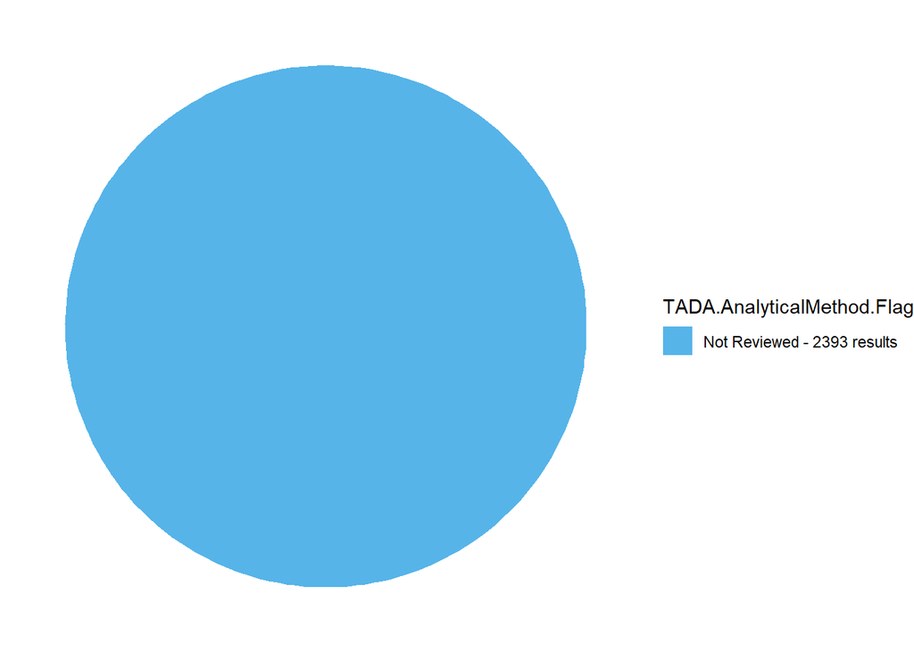

```r
TADA_FieldValuesPie(flagged_result_unit, field = "TADA.AnalyticalMethod.Flag")
```

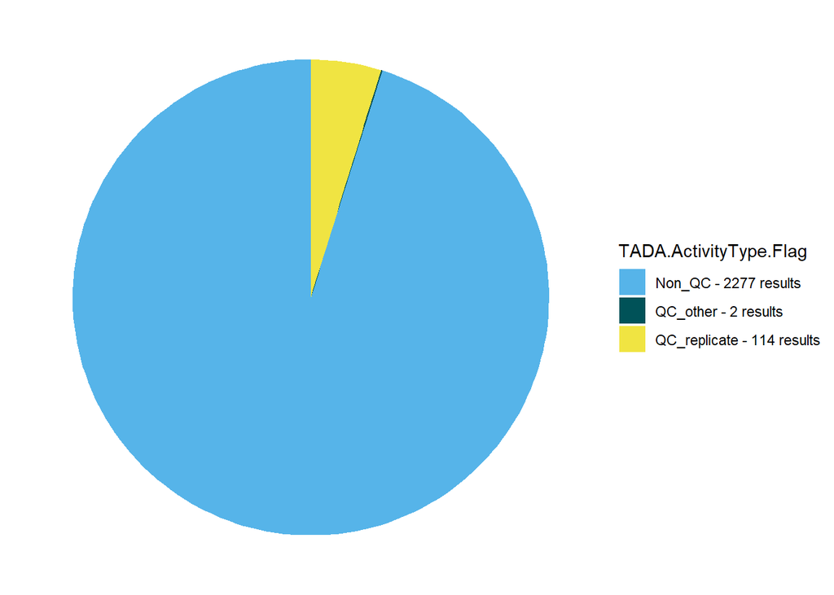

```r
TADA_FieldValuesPie(flagged_result_unit, field = "TADA.ActivityType.Flag")
```

Removing untrustworthy flags.

```r
problem_flagged <- flagged_result_unit %>%
  filter(TADA.SampleFraction.Flag == "Suspect" | TADA.MethodSpeciation.Flag == "Suspect" | TADA.ResultUnit.Flag == "Suspect" | !TADA.ActivityType.Flag %in% c("Non_QC", "Not Reviewed") | TADA.AnalyticalMethod.Flag == "Suspect") %>%
  mutate(TADA.RemovalReason = "Invalid Unit, Method, Speciation, or Activity Type.")
# 903 observations

after_flags <- flagged_result_unit %>%
  filter(!ResultIdentifier %in% problem_flagged$ResultIdentifier)
# 1490 observations
```

The `TADA_IDCensoredData()` function imputes non-detects for TADA.ResultMeasureValue. I dont’ want that so I’m to see what the ResultDetectionCondition and DetectionQuantitationLimitTypeName fields look like. These are the fields the TADA_IDCensoredData functions uses to create the flags.

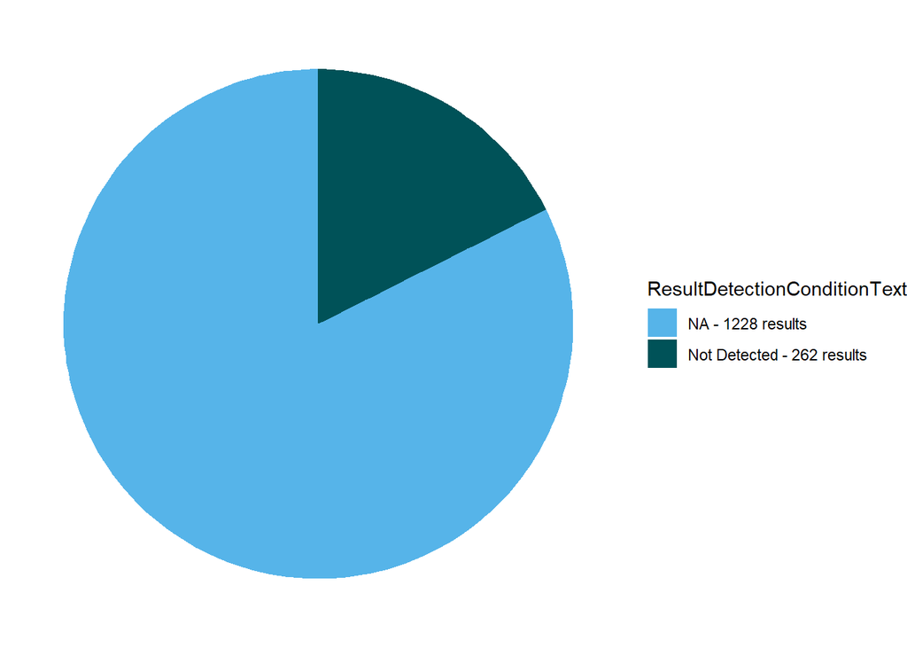

```r
TADA_FieldValuesPie(after_flags, field = "ResultDetectionConditionText")
```

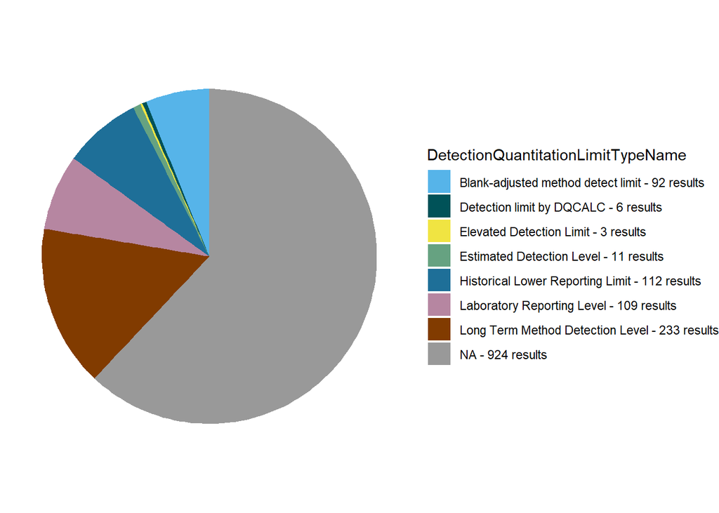

```r
TADA_FieldValuesPie(after_flags, field = "DetectionQuantitationLimitTypeName")
```

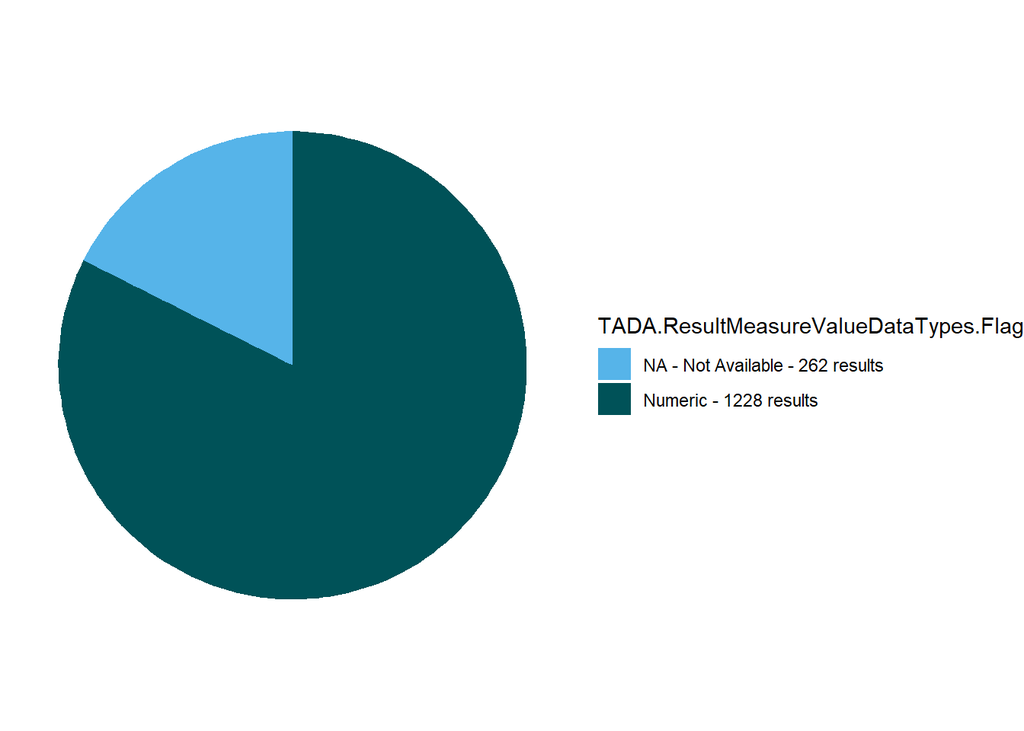

```r
TADA_FieldValuesPie(after_flags, field = "TADA.ResultMeasureValueDataTypes.Flag")
```

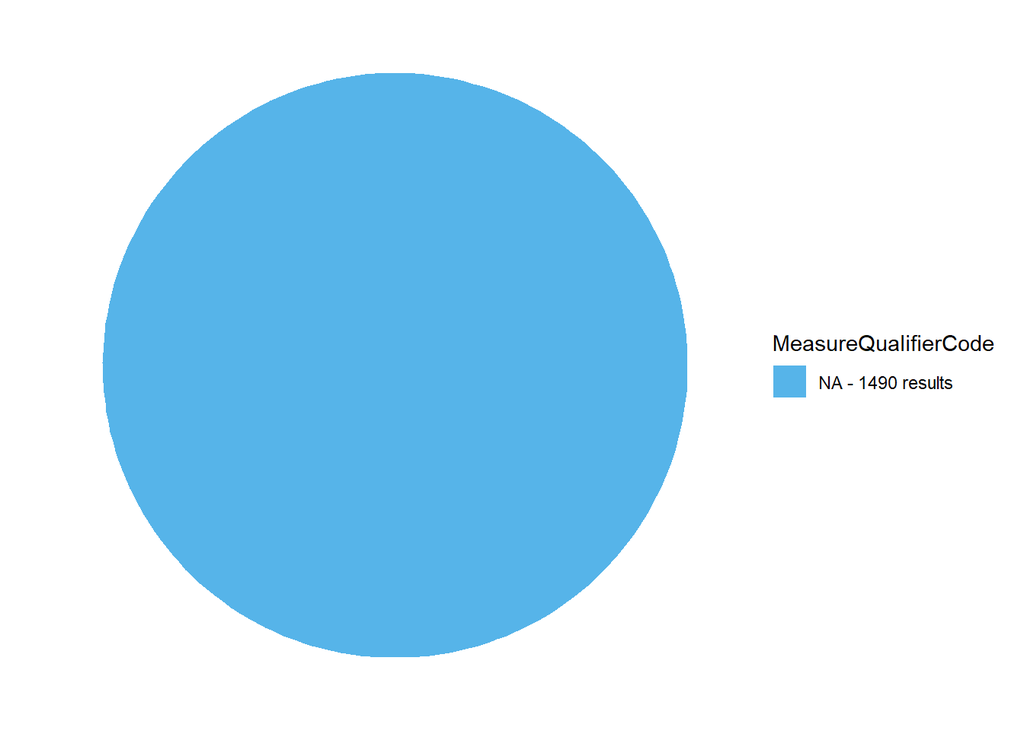

```r
TADA_FieldValuesPie(after_flags, field = "MeasureQualifierCode")
```

```r
problem_censored <- after_flags %>%
  filter(ResultDetectionConditionText %in% c("Detected Not Quantified", "Systematic Contamination") | MeasureQualifierCode == "J") %>%
  mutate(TADA.RemovalReason = "Invalid Censored Data.")
# 0 observations

after_censored <- after_flags %>%
  filter(!ResultIdentifier %in% problem_censored$ResultIdentifier)
# 1490 observations
```

Flagging duplicate efforts

```r
single_org_flagged <- TADA_FindPotentialDuplicatesSingleOrg(after_censored)
```

[output not shown]

```r
# [1] "TADA_FindPotentialDuplicatesSingleOrg: 53 groups of potentially duplicated results found in dataset. These have been placed into duplicate groups in the TADA.SingleOrgDupGroupID column and the function randomly selected one result from each group to represent a single, unduplicated value. Selected values are indicated in the TADA.SingleOrgDup.Flag as 'Unique', while duplicates are flagged as 'Duplicate' for easy filtering."

after_single <- single_org_flagged %>%
  filter(!TADA.SingleOrgDup.Flag %in% "Duplicate")
# 1437 observations

multiple_org_flagged <- TADA_FindPotentialDuplicatesMultipleOrgs(after_single)
```

```
## Transforming your data into a spatial object.
```

```
## [1] "TADA_FindNearbySites: No org_hierarchy supplied by user. Organization will not be taken into account during metadata selection."
## [1] "No duplicate results detected. Returning input dataframe with duplicate flagging columns set to 'N'."
```

```r
# [1] "TADA_FindNearbySites: No org_hierarchy supplied by user. Organization will not be taken into account during metadata selection."
# [1] "No duplicate results detected. Returning input dataframe with duplicate flagging columns set to 'N'."
```

Harmonizing Nitrate Units, Fractionation, Speciation

```r
constituent_data <- after_single %>%
  filter(TADA.CharacteristicName == "NITRATE" | TADA.CharacteristicName == "ARSENIC" | TADA.CharacteristicName == "LEAD")

# fraction assumption: dissolved = filtered
# fraction assumption: total = unfiltered
constituents_harmonized <- constituent_data %>%
  filter(TADA.ResultSampleFractionText %in% c(
    "DISSOLVED",
    "FILTERED"
    )) %>%
  filter(is.na(ResultDetectionConditionText) | ResultDetectionConditionText == "Not Detected") %>%
  mutate(
    TADA.ResultSampleFractionText = case_when(
      TADA.ResultSampleFractionText == "DISSOLVED" ~ "FILTERED",
      TRUE ~ TADA.ResultSampleFractionText
      ),

    TADA.ResultMeasureValue = case_when(
      TADA.MethodSpeciationName == "AS NO3" ~ TADA.ResultMeasureValue * 0.225,
      TRUE ~ TADA.ResultMeasureValue
    ),

    TADA.MethodSpeciationName = case_when(
      TADA.MethodSpeciationName %in% "AS NO3" ~ "AS N",
      TRUE ~ TADA.MethodSpeciationName
    ),

    numeric_well_depth = as.numeric(`WellDepthMeasure.MeasureValue`),
    numeric_hole_depth = as.numeric(`WellHoleDepthMeasure.MeasureValue`),

    well_depth = case_when(
      `WellDepthMeasure.MeasureUnitCode` == "ft" ~ `numeric_well_depth` * 0.3048,
      TRUE ~ as.numeric(`numeric_well_depth`)
    ),
    well_depth_unit = case_when(
      `WellDepthMeasure.MeasureUnitCode` == "ft" ~ "m",
      TRUE ~ `WellDepthMeasure.MeasureUnitCode`
    ),
    hole_depth = case_when(
      `WellHoleDepthMeasure.MeasureUnitCode` == "ft" ~ `numeric_hole_depth` * 0.3048,
      TRUE ~ as.numeric(`numeric_hole_depth`)
    ),
    hole_depth_unit = case_when(
      `WellHoleDepthMeasure.MeasureUnitCode` == "ft" ~ "m",
      TRUE ~ `WellHoleDepthMeasure.MeasureUnitCode`
    )
  )
# 1023 observations

hardness_harmonized <- after_single %>%
  filter(TADA.CharacteristicName == "HARDNESS, CA, MG") %>%
  mutate(
    numeric_well_depth = as.numeric(`WellDepthMeasure.MeasureValue`),
    numeric_hole_depth = as.numeric(`WellHoleDepthMeasure.MeasureValue`),

    well_depth = case_when(
      `WellDepthMeasure.MeasureUnitCode` == "ft" ~ `numeric_well_depth` * 0.3048,
      TRUE ~ as.numeric(`numeric_well_depth`)
    ),
    well_depth_unit = case_when(
      `WellDepthMeasure.MeasureUnitCode` == "ft" ~ "m",
      TRUE ~ `WellDepthMeasure.MeasureUnitCode`
    ),
    hole_depth = case_when(
      `WellHoleDepthMeasure.MeasureUnitCode` == "ft" ~ `numeric_hole_depth` * 0.3048,
      TRUE ~ as.numeric(`numeric_hole_depth`)
    ),
    hole_depth_unit = case_when(
      `WellHoleDepthMeasure.MeasureUnitCode` == "ft" ~ "m",
      TRUE ~ `WellHoleDepthMeasure.MeasureUnitCode`
  ))
# 298 observations

all_data <- bind_rows(constituents_harmonized, hardness_harmonized)
# 1321 observations

write.csv(all_data, "../input/processed/WQP/clean_params.csv")
```

```r
params <- read.csv("../input/processed/WQP/clean_params.csv")
```

In the ArcGIS Pro project titled “WQP_Params” I brought in my PR map and “../input/processed/WQP/clean_params.csv”. I used the spatial join tool and calculated a field in clean_params to be physiographic region. The output for this work is “..input/processed/WQP/cleans_params_prs”.

I’m going to read in the WQP data with “PR” attributed to each point.

```r
params <- read.csv("../input/processed/WQP/clean_params_prs.csv") %>%
  filter(!PR %in% "")

PRs <- unique(params$PR)

PRs
```

```
## [1] "East Gulf Coastal Plain"  "Highland Rim"
## [3] "Alabama Valley and Ridge" "Piedmont Upland"
```

```r
# [1]  "East Gulf Coastal Plain"  "Highland Rim"             "Alabama Valley and Ridge" "Piedmont Upland"

# there is no data for the Cumberland Plateau
PR_colors <- c(
  "Alabama Valley and Ridge" = "#C99ADA",
  "East Gulf Coastal Plain" = "#BED2E5",
  "Highland Rim" = "#CC9593",
  "Piedmont Upland" = "#E4BBD2"
)
```

Arsenic

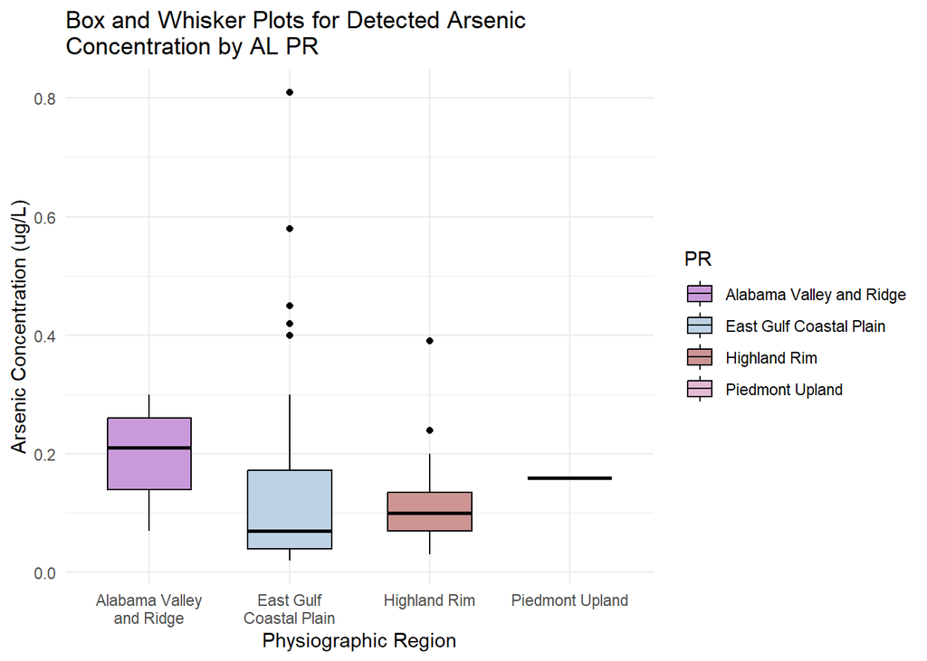

```r
# filtering the dataset to arsenic samples
arsenic <- params %>%
  filter(TADA_CharacteristicName %in% "ARSENIC")

arsenic_stats <- arsenic %>%
  mutate(
    median = median(TADA_ResultMeasureValue, na.rm = TRUE),
      q1 = quantile(TADA_ResultMeasureValue, 0.25, na.rm = TRUE),
      q3 = quantile(TADA_ResultMeasureValue, 0.75, na.rm = TRUE)
  )

boxwhisk_arsenic <- ggplot(arsenic_stats, aes(
  x = fct_reorder(PR, median, .desc = TRUE),
  y = TADA_ResultMeasureValue,
  fill = PR
)) +
  geom_boxplot(
    color = "black",
    width = 0.6,
    position = position_dodge2(width = 1, preserve = "single"), # preserves box width
  ) +
  scale_fill_manual(values = PR_colors) +
  scale_x_discrete(labels = function(x) str_wrap(x, width = 15)) +
  labs(
    title = str_wrap(
      "Box and Whisker Plots for Detected Arsenic Concentration by AL PR",
      width = 50
    ),
    x = "Physiographic Region",
    y = "Arsenic Concentration (ug/L)"
  ) +
  theme_minimal() +
  theme(
    legend.position = "right"
  )

boxwhisk_arsenic
```

Nitrate

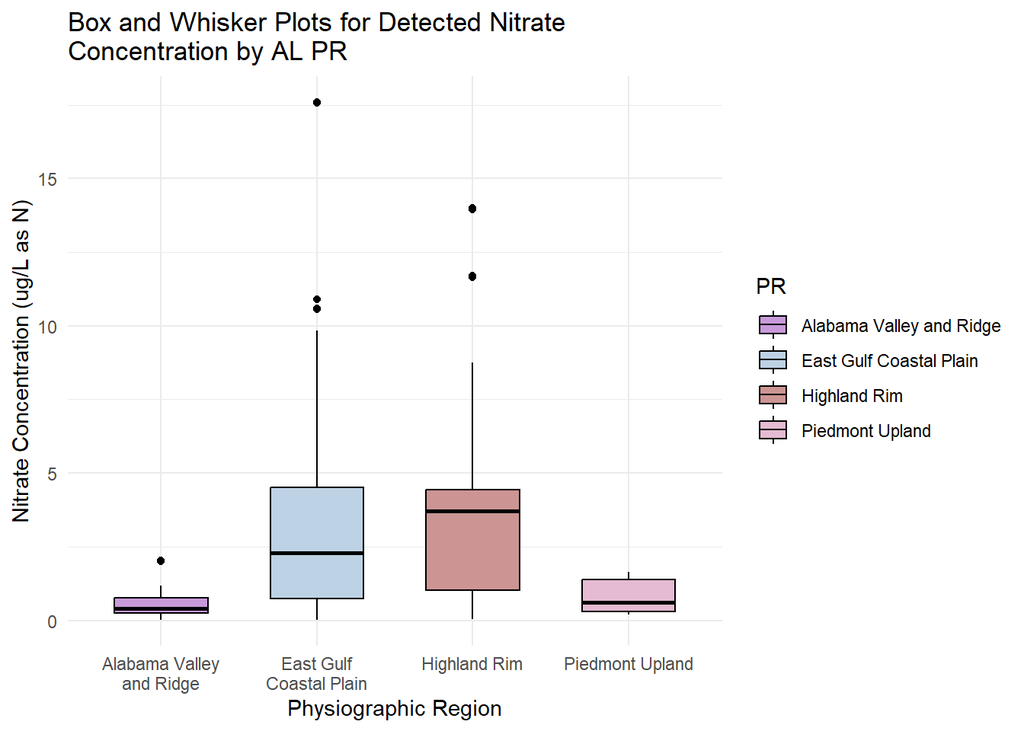

```r
# filtering the dataset to nitrate samples
nitrate <- params %>%
  filter(TADA_CharacteristicName %in% "NITRATE")

nitrate_stats <- nitrate %>%
  mutate(
    median = median(TADA_ResultMeasureValue, na.rm = TRUE),
      q1 = quantile(TADA_ResultMeasureValue, 0.25, na.rm = TRUE),
      q3 = quantile(TADA_ResultMeasureValue, 0.75, na.rm = TRUE)
  )

boxwhisk_nitrate <- ggplot(nitrate_stats, aes(
  x = fct_reorder(PR, median, .desc = TRUE),
  y = TADA_ResultMeasureValue,
  fill = PR
)) +
  geom_boxplot(
    color = "black",
    width = 0.6,
    position = position_dodge2(width = 1, preserve = "single"), # preserves box width
  ) +
  scale_fill_manual(values = PR_colors) +
  scale_x_discrete(labels = function(x) str_wrap(x, width = 15)) +
  labs(
    title = str_wrap(
      "Box and Whisker Plots for Detected Nitrate Concentration by AL PR",
      width = 50
    ),
    x = "Physiographic Region",
    y = "Nitrate Concentration (ug/L as N)"
  ) +
  theme_minimal() +
  theme(
    legend.position = "right"
  )

boxwhisk_nitrate
```

Lead

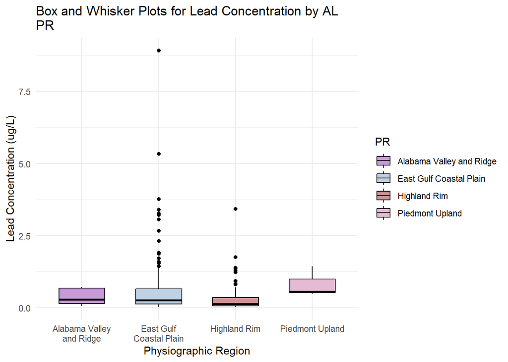

```r
# filtering the dataset to lead samples
lead <- params %>%
  filter(TADA_CharacteristicName %in% "LEAD")

lead_stats <- lead %>%
  mutate(
    median = median(TADA_ResultMeasureValue, na.rm = TRUE),
      q1 = quantile(TADA_ResultMeasureValue, 0.25, na.rm = TRUE),
      q3 = quantile(TADA_ResultMeasureValue, 0.75, na.rm = TRUE)
  )

boxwhisk_lead <- ggplot(lead_stats, aes(
  x = fct_reorder(PR, median, .desc = TRUE),
  y = TADA_ResultMeasureValue,
  fill = PR
)) +
  geom_boxplot(
    color = "black",
    width = 0.6,
    position = position_dodge2(width = 1, preserve = "single"), # preserves box width
  ) +
  scale_fill_manual(values = PR_colors) +
  scale_x_discrete(labels = function(x) str_wrap(x, width = 15)) +
  labs(
    title = str_wrap(
      "Box and Whisker Plots for Lead Concentration by AL PR",
      width = 50
    ),
    x = "Physiographic Region",
    y = "Lead Concentration (ug/L)"
  ) +
  theme_minimal() +
  theme(
    legend.position = "right"
  )

boxwhisk_lead
```

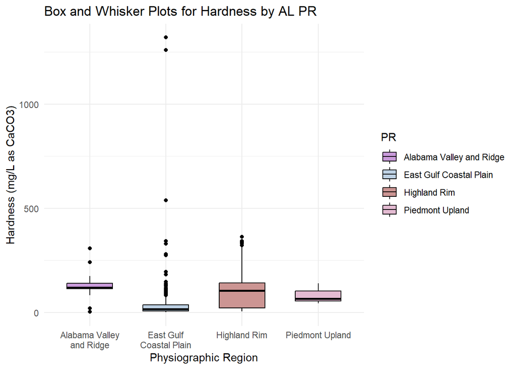

```r
hardness <- params %>%
  filter(TADA_CharacteristicName %in% "HARDNESS, CA, MG")

hardness_stats <- hardness %>%
  mutate(
    median = median(TADA_ResultMeasureValue, na.rm = TRUE),
      q1 = quantile(TADA_ResultMeasureValue, 0.25, na.rm = TRUE),
      q3 = quantile(TADA_ResultMeasureValue, 0.75, na.rm = TRUE)
  )

boxwhisk_hardness <- ggplot(hardness_stats, aes(
  x = fct_reorder(PR, median, .desc = TRUE),
  y = TADA_ResultMeasureValue,
  fill = PR
)) +
  geom_boxplot(
    color = "black",
    width = 0.6,
    position = position_dodge2(width = 1, preserve = "single"), # preserves box width
  ) +
  scale_fill_manual(values = PR_colors) +
  scale_x_discrete(labels = function(x) str_wrap(x, width = 15)) +
  labs(
    title = str_wrap(
      "Box and Whisker Plots for Hardness by AL PR",
      width = 50
    ),
    x = "Physiographic Region",
    y = "Hardness (mg/L as CaCO3)"
  ) +
  theme_minimal() +
  theme(
    legend.position = "right"
  )

boxwhisk_hardness
```

Performing kruskal-wallis test to see whether median arsenic, lead, nitrate, or hardness are different across physiographic regions.

```r
# hardness
kruskal.test(TADA_ResultMeasureValue ~ PR, data = hardness_stats)
```

```
##
##  Kruskal-Wallis rank sum test
##
## data:  TADA_ResultMeasureValue by PR
## Kruskal-Wallis chi-squared = 81.362, df = 3, p-value < 2.2e-16
```

```r
# Kruskal-Wallis chi-squared = 81.362, df = 3, p-value < 2.2e-16

dunnTest(TADA_ResultMeasureValue ~ PR, data = hardness_stats, method = "bh")
```

```
## Dunn (1964) Kruskal-Wallis multiple comparison
```

```
##   p-values adjusted with the Benjamini-Hochberg method.
```

```
##                                           Comparison          Z      P.unadj
## 1 Alabama Valley and Ridge - East Gulf Coastal Plain  6.2895905 3.183046e-10
## 2            Alabama Valley and Ridge - Highland Rim  1.5637363 1.178795e-01
## 3             East Gulf Coastal Plain - Highland Rim -7.5176687 5.576158e-14
## 4         Alabama Valley and Ridge - Piedmont Upland  0.3477780 7.280069e-01
## 5          East Gulf Coastal Plain - Piedmont Upland -1.9039139 5.692140e-02
## 6                     Highland Rim - Piedmont Upland -0.2319107 8.166074e-01
##          P.adj
## 1 9.549137e-10
## 2 1.768192e-01
## 3 3.345695e-13
## 4 8.736083e-01
## 5 1.138428e-01
## 6 8.166074e-01
```

```r
# lead
kruskal.test(TADA_ResultMeasureValue ~ PR, data = lead_stats)
```

```
##
##  Kruskal-Wallis rank sum test
##
## data:  TADA_ResultMeasureValue by PR
## Kruskal-Wallis chi-squared = 11.311, df = 3, p-value = 0.01016
```

```r
# Kruskal-Wallis chi-squared = 11.311, df = 3, p-value = 0.01016

dunnTest(TADA_ResultMeasureValue ~ PR, data = lead_stats, method = "bh")
```

```
## Dunn (1964) Kruskal-Wallis multiple comparison
```

```
##   p-values adjusted with the Benjamini-Hochberg method.
```

```
##                                           Comparison          Z     P.unadj
## 1 Alabama Valley and Ridge - East Gulf Coastal Plain -0.1234335 0.901763816
## 2            Alabama Valley and Ridge - Highland Rim  1.1653067 0.243894860
## 3             East Gulf Coastal Plain - Highland Rim  2.9496513 0.003181328
## 4         Alabama Valley and Ridge - Piedmont Upland -1.2089506 0.226681817
## 5          East Gulf Coastal Plain - Piedmont Upland -1.3223116 0.186064428
## 6                     Highland Rim - Piedmont Upland -2.1240525 0.033665757
##        P.adj
## 1 0.90176382
## 2 0.29267383
## 3 0.01908797
## 4 0.34002272
## 5 0.37212886
## 6 0.10099727
```

```r
# nitrate
kruskal.test(TADA_ResultMeasureValue ~ PR, data = nitrate_stats)
```

```
##
##  Kruskal-Wallis rank sum test
##
## data:  TADA_ResultMeasureValue by PR
## Kruskal-Wallis chi-squared = 56.678, df = 3, p-value = 3.01e-12
```

```r
# Kruskal-Wallis chi-squared = 56.678, df = 3, p-value = 3.01e-12

dunnTest(TADA_ResultMeasureValue ~ PR, data = nitrate_stats, method = "bh")
```

```
## Dunn (1964) Kruskal-Wallis multiple comparison
```

```
##   p-values adjusted with the Benjamini-Hochberg method.
```

```
##                                           Comparison          Z      P.unadj
## 1 Alabama Valley and Ridge - East Gulf Coastal Plain -6.1559726 7.461814e-10
## 2            Alabama Valley and Ridge - Highland Rim -7.2043428 5.832448e-13
## 3             East Gulf Coastal Plain - Highland Rim -2.4154235 1.571692e-02
## 4         Alabama Valley and Ridge - Piedmont Upland -0.3722929 7.096748e-01
## 5          East Gulf Coastal Plain - Piedmont Upland  2.1717799 2.987227e-02
## 6                     Highland Rim - Piedmont Upland  2.7026186 6.879563e-03
##          P.adj
## 1 2.238544e-09
## 2 3.499469e-12
## 3 2.357538e-02
## 4 7.096748e-01
## 5 3.584672e-02
## 6 1.375913e-02
```

```r
# arsenic
kruskal.test(TADA_ResultMeasureValue ~ PR, data = arsenic_stats)
```

```
##
##  Kruskal-Wallis rank sum test
##
## data:  TADA_ResultMeasureValue by PR
## Kruskal-Wallis chi-squared = 8.4036, df = 3, p-value = 0.03837
```

```r
# Kruskal-Wallis chi-squared = 8.4036, df = 3, p-value = 0.03837

dunnTest(TADA_ResultMeasureValue ~ PR, data = arsenic_stats, method = "bh")
```

```
## Dunn (1964) Kruskal-Wallis multiple comparison
```

```
##   p-values adjusted with the Benjamini-Hochberg method.
```

```
##                                           Comparison          Z     P.unadj
## 1 Alabama Valley and Ridge - East Gulf Coastal Plain  2.6702003 0.007580602
## 2            Alabama Valley and Ridge - Highland Rim  1.9068731 0.056537025
## 3             East Gulf Coastal Plain - Highland Rim -1.3008706 0.193302737
## 4         Alabama Valley and Ridge - Piedmont Upland  0.1122253 0.910644773
## 5          East Gulf Coastal Plain - Piedmont Upland -0.9357457 0.349404114
## 6                     Highland Rim - Piedmont Upland -0.6601818 0.509137152
##        P.adj
## 1 0.04548361
## 2 0.16961107
## 3 0.38660547
## 4 0.91064477
## 5 0.52410617
## 6 0.61096458
```